# MIE237

2016-01-22

## A taste of categorical data 9.10, 10.13

## Example "gas pipeline data"

[output not shown]

## Numbers of interest

- Counts and *proportions* of one- and multi-way classifications.
- One-way on `Leak`:

```
## Source: local data frame [2 x 3]
##
##    Leak Count Proportion
##   (chr) (int)      (dbl)
## 1    No   802      0.802
## 2   Yes   198      0.198
```

- Note: avoid "percentages", which are really just a way of formatting proportions for human visual consumption.

## numbers…two-way classification

- A few different styles…

```
##      Size
## Leak    1 1.5 1.75
##   No  329 249  224
##   Yes  93  52   53
```

```
## Source: local data frame [6 x 3]
## Groups: Leak [?]
##
##    Leak  Size     n
##   (chr) (dbl) (int)
## 1    No  1.00   329
## 2    No  1.50   249
## 3    No  1.75   224
## 4   Yes  1.00    93
## 5   Yes  1.50    52
## 6   Yes  1.75    53
```

## numbers…two-way classification

- Adding marginal totals:

```
##      Size
## Leak     1  1.5 1.75  Sum
##   No   329  249  224  802
##   Yes   93   52   53  198
##   Sum  422  301  277 1000
```

- Proportions rather than counts:

```
##      Size
## Leak      1   1.5  1.75   Sum
##   No  0.329 0.249 0.224 0.802
##   Yes 0.093 0.052 0.053 0.198
##   Sum 0.422 0.301 0.277 1.000
```

## graphical summaries

- Pretty much "bar plot" or "bar chart" and friends

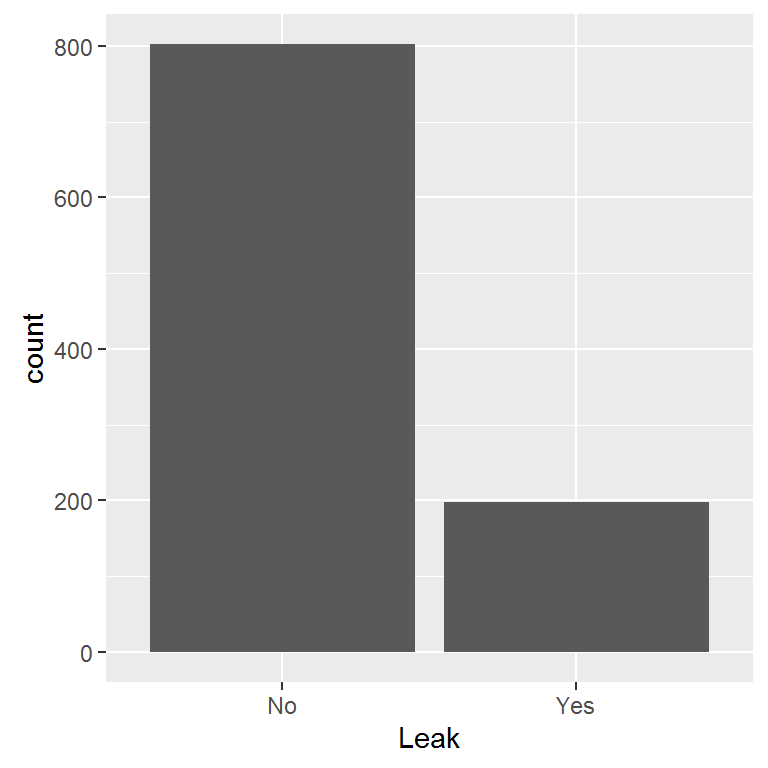

```r
pipeline %>%
  ggplot(aes(x = Leak)) + geom_bar()
```

## R diversion: factor

- In R a `factor` is a special kind of variable, specifically for categorical variables. The values of a `factor` variable are restricted to certain `levels`.
- Let's look at what R thinks the variables of `pipeline` are made of:

```r
str(pipeline)
```

```
## Classes 'tbl_df', 'tbl' and 'data.frame':    1000 obs. of  4 variables:
##  $ Leak    : chr  "No" "No" "No" "Yes" ...
##  $ Size    : num  1.75 1.75 1 1.5 1 1 1.75 1.75 1.5 1.75 ...
##  $ Material: chr  "Aldyl A" "Aldyl A" "Aldyl A" "Steel" ...
##  $ Pressure: chr  "High" "Med" "Low" "Med" ...
```

- OK, three `character` variables and one `numerical` variable.

## R diversion: factor

- The first 10 elements of `Leak`

```r
pipeline$Leak[1:10]
```

```
##  [1] "No"  "No"  "No"  "Yes" "No"  "Yes" "Yes" "No"  "No"  "No"
```

- Let's explicitly change `Leak` to a `factor` type and look at things again…

## R diversion: factor

```r
pipeline$Leak <- factor(pipeline$Leak)
str(pipeline)
```

```
## Classes 'tbl_df', 'tbl' and 'data.frame':    1000 obs. of  4 variables:
##  $ Leak    : Factor w/ 2 levels "No","Yes": 1 1 1 2 1 2 2 1 1 1 ...
##  $ Size    : num  1.75 1.75 1 1.5 1 1 1.75 1.75 1.5 1.75 ...
##  $ Material: chr  "Aldyl A" "Aldyl A" "Aldyl A" "Steel" ...
##  $ Pressure: chr  "High" "Med" "Low" "Med" ...
```

```r
pipeline$Leak[1:10]
```

```
##  [1] No  No  No  Yes No  Yes Yes No  No  No
## Levels: No Yes
```

- The tricky thing is that R will often, but not always, temporarily *coerce* variables to be `factor` type when it seems to make sense. This is in a sense related to the sometimes arbitrary division we make between *numerical* and *categorical*

## Plot where R guesses wrong

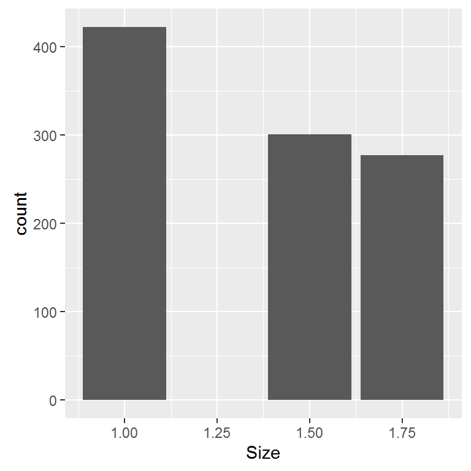

```r
pipeline %>%
  ggplot(aes(x = Size)) + geom_bar()
```

## Explicitly declare a factor variable

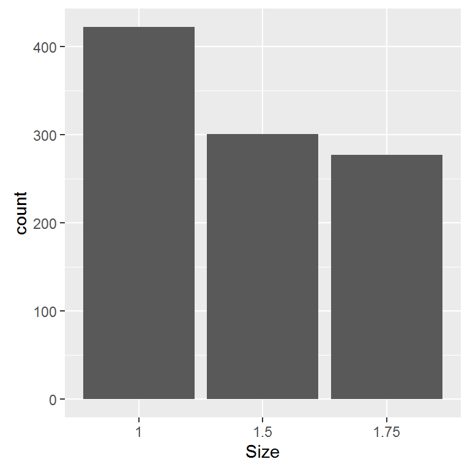

```r
pipeline %>%
  ggplot(aes(x = factor(Size))) + geom_bar() + xlab("Size")
```

## Plots for two-way classifications

- Stacked bar plot

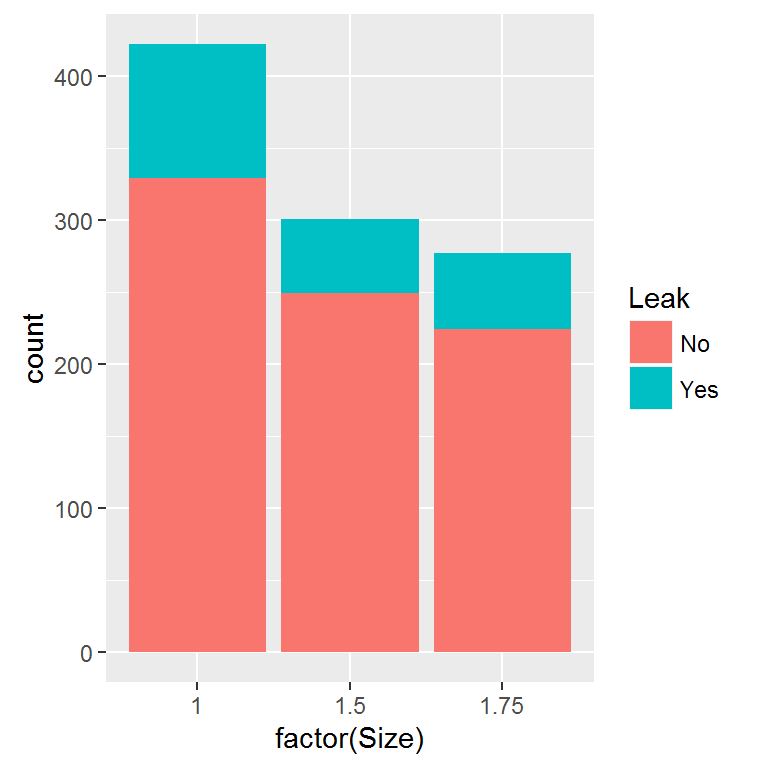

## Plots for two-way classifications

- Not sure what this is called, but with proportions rather than counts

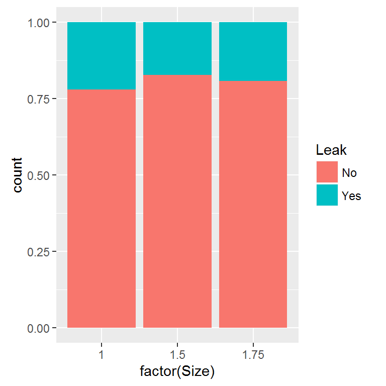

## Crappy plot from hell that deserves to die

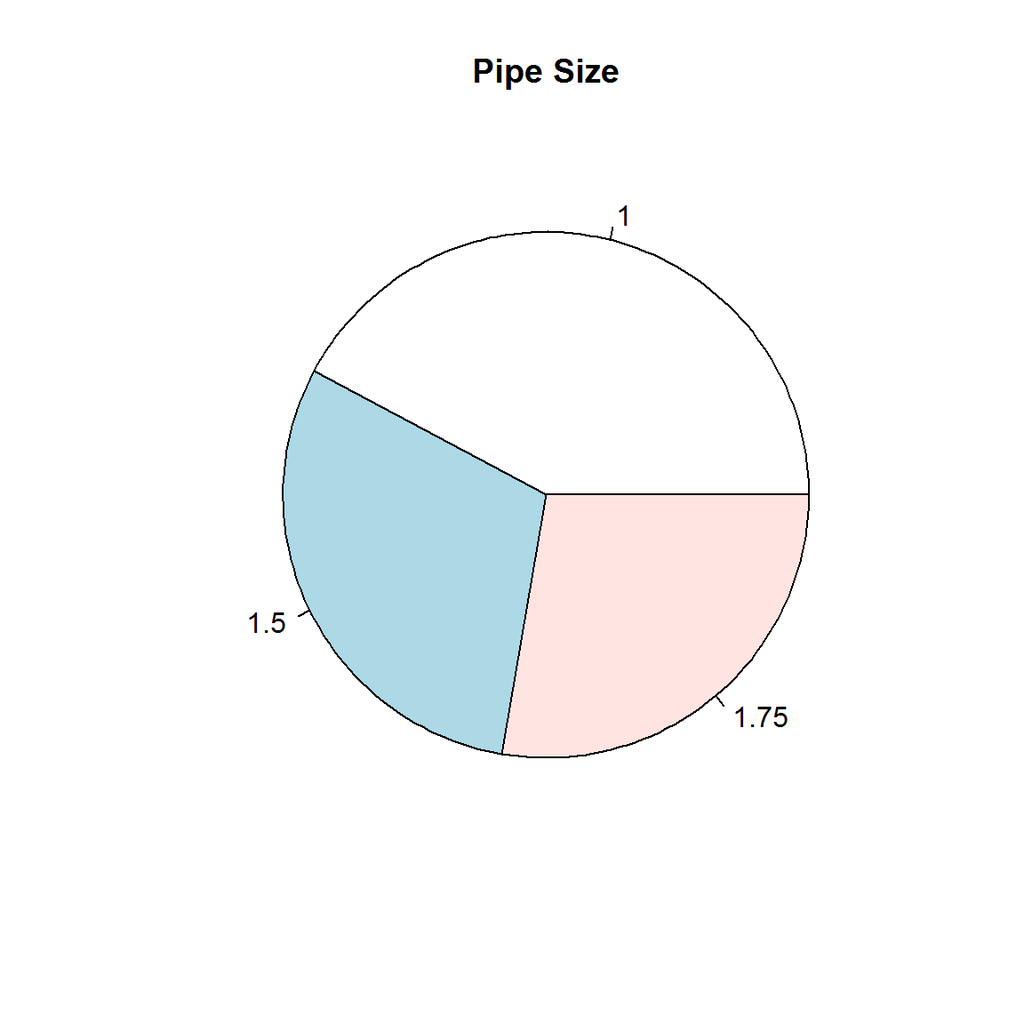

## Inference for one-way classifications

Old model: population \(X \sim N(\mu, \sigma^2)\)

New model:\[\begin{equation*} X = \begin{cases} 1 & \text{ with probability } p,\\ 0 & \text{ with probability } 1-p \end{cases} \end{equation*}\]

Or: \(X \sim \text{Bernoulli}(p)\) (feel the Bern!)

Recall: \({E\left( X \right)} = p\) and \(Var(X) = p(1-p)\).

We don't know \(p\). So as usual we (plan to) gather a sample \({X_1, X_2, \ldots, X_n}\)

## How to estimate \(p\)?

- Same as before: use \({\overline{X}}\), for suppose \(k\) is the number of "successes" (or "1"s) and think about how \(k/n\) is the same as \({\overline{X}}\).
- The traditional notation for this case is \(\hat{p}\), but it's nothing more than \({\overline{X}}\).
- All the usual results follow:\[\begin{align*} {E\left( \hat{p} \right)} &= p\\ Var(\hat{p}) &= \frac{p(1-p)}{n} \end{align*}\]
- Getting close to the "Key Fact". We have the usual:\[\frac{\hat{p} - p}{\sqrt{\frac{p(1-p)}{n}}} \sim^{\text{approx.}} N(0,1)\]

## Confidence interval for a proportion

- As usual *Estimator +/- "2" times standard error*:\[\hat{p} \pm z_{\alpha/2}\sqrt{\frac{p(1-p)}{n}}\]except for the usual problem…
- Simplest fix is to just replace \(p\) with its estimate \(\hat{p}\).
- (Optional material) Actually a really badly performing confidence interval.

## Another confidence interval for a proportion (OPTIONAL)

- The simplest interval is based on the approximation:\[1-\alpha = P\left(-z_{\alpha/2} < \frac{\hat{p} - p}{\sqrt{\frac{p(1-p)}{n}}} < z_{\alpha/2}\right)\approx P\left(-z_{\alpha/2} < \frac{\hat{p} - p}{\sqrt{\frac{\hat{p}(1-{p})}{n}}} < z_{\alpha/2}\right)\]
- A better performing interval is based on solving for \(p\) directly:\[-z_{\alpha/2} < \frac{\hat{p} - p}{\sqrt{\frac{p(1-p)}{n}}} < z_{\alpha/2}\]

## Another confidence interval for a proportion (OPTIONAL)

Solution isn't so simple:

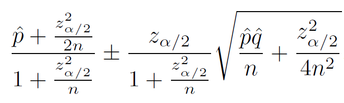

The interval \(\tilde{p} \pm z_{\alpha/2}\sqrt{\frac{\tilde{p}(1-\tilde{p})}{n}}\) performs better.

## Model assumptions

- As usual depends on the skewness of the underlying distribution…
- Use the heuristic: \(n\hat{p}\) and \(n(1-\hat{p})\) both exceed 5.

## Inference for two-way classifications

```
##      Size
## Leak    1 1.5 1.75
##   No  329 249  224
##   Yes  93  52   53
```

- Main problem is to test if the rows and columns are either:
  - independent (language used when row *and* column totals are random)
  - "homogeneous" (language used when row *or* column totals are fixed in advance)
- Math is the same either way. So we'll focus on the question of "independence"
- Null hypothesis of the test: *rows and columns are independent*.

## What does independence mean in this context?

Independence is a property of two random variables. In this case, two discrete random variables. The "model" is (for example in a 2x3 table)

| Row/Column | 1 | 2 | 3 | Row margin |
| --- | --- | --- | --- | --- |
| 1 | \(\pi_{11}\) | \(\pi_{12}\) | \(\pi_{13}\) | \(\pi_{1\cdot}\) |
| 2 | \(\pi_{21}\) | \(\pi_{22}\) | \(\pi_{23}\) | \(\pi_{2\cdot}\) |
| Column margin | \(\pi_{\cdot 1}\) | \(\pi_{\cdot 2}\) | \(\pi_{\cdot 3}\) | 1 |

The null hypothesis is then technically:\[\pi_{ij} = \pi_{i\cdot}\pi_{\cdot j} \text{ for all } i,j\]

## Method

- Treat marginal totals as fixed
- Compute *expected cell counts* \(E_i\) assuming independence
- With \(O_i\) as *observed cell counts* use the following test statistic:

\[\sum_i \frac{\left(O_i - E_i\right)^2}{E_i} \sim^{\text{approx}} \chi^2_{(r-1)(c-1)}\]

- Approximation is good if \(E_i \ge 5\) for all \(i\).